# Machine Learning Peer Assessment Project

Tim Gaertner

March 16, 2015

# 1 Download and Read-In Raw Data

- Download and Read in Training Data

```r
fileUrl <- "https://d396qusza40orc.cloudfront.net/predmachlearn/pml-training.csv"
if (!file.exists("training.csv")) {download.file(url = fileUrl, destfile = "training.csv")}
trainingData <- read.csv(file = "training.csv")
```

- Download and Read in Testing Data

```r
fileUrl <- "https://d396qusza40orc.cloudfront.net/predmachlearn/pml-testing.csv"
if (!file.exists("testing.csv")) {download.file(url = fileUrl, destfile = "testing.csv")}
testingData <- read.csv(file = "testing.csv")
```

# 2 Pre-Processing

- Clean `cvtd_timestamp` variable by formatting as a date
- Format all number based variables as numeric
- Remove variables `X`,`user_name`, and `new_window` from model consideration as they cannot be used to score the testing data

```r
trainingData$cvtd_timestamp <- as.Date(trainingData$cvtd_timestamp,"%m/%d/%Y %H:%M")

for (i in 1:length(names(trainingData))) {
        if (grepl("dumbbell|forearm|arm|belt",names(trainingData)[i])){
                trainingData[,i] <- as.numeric(trainingData[,i])
        }
}

trainingData <- trainingData[,c(-1,-2,-6)]
```

## 2.1 Creating Dummy Variables

- Convert all factor variables to dummy variables

```r
library(caret)
```

```r
dummies <- dummyVars(classe ~ ., trainingData)
numData <- as.data.frame(predict(dummies, trainingData))
```

## 2.2 Zero and Near-Zero Variance Predictors

- Remove all covariates from model consideration which have zero or near-zero variance

```r
nzv <- nearZeroVar(numData, saveMetrics= TRUE)
dim(numData)
```

```
## [1] 19622   156
```

```r
nzv <- nearZeroVar(numData)
filteredData <- numData[, -nzv]
dim(filteredData)
```

```
## [1] 19622    97
```

## 2.3 Data Cleansing

- Replaces all missing values (NA) with 0

```r
for (j in 1:length(names(filteredData))) {
        for (i in 1:nrow(filteredData)) {
              if (is.na(filteredData[i,j])) {filteredData[i,j] <- 0}
        }
}
```

## 2.4 Identifying Correlated Predictors

- Remove highly correlated covariates from model consideration

```r
dataCor <-  cor(filteredData)
highCorr <- sum(abs(dataCor[upper.tri(dataCor)]) > .999)
summary(dataCor[upper.tri(dataCor)])
```

```
##      Min.   1st Qu.    Median      Mean   3rd Qu.      Max.
## -0.992000 -0.020680  0.002072  0.035600  0.048330  0.993600
```

```r
highlyCorData <- findCorrelation(dataCor, cutoff = .75)
filteredData <- filteredData[,-highlyCorData]
dataCor2 <- cor(filteredData[,sapply(filteredData, is.numeric)])
summary(dataCor2[upper.tri(dataCor2)])
```

```
##       Min.    1st Qu.     Median       Mean    3rd Qu.       Max.
## -0.6998000 -0.0234000  0.0006374  0.0113000  0.0378900  0.7158000
```

```r
numCov <- dim(filteredData)[2]
```

- Before modeling, we are left with 56 covariates for model consideration

## 2.5 Partition Training and Testing Sets

```r
classe <- as.vector(trainingData[,"classe"])

trainingData <- cbind(classe, filteredData)

set.seed(1)
inTrain <- createDataPartition(y = trainingData$classe,
                               p=0.5,
                               list = FALSE)
training <- trainingData[inTrain,]
testing <- trainingData[-inTrain,]
dim(training); dim(testing)
```

[output not shown]

# 3 Modeling

## 3.1 Model Building

```r
cvCtrl <- trainControl(method = "repeatedcv", repeats = 3)

set.seed(1)
rfTune <- train(classe ~ .,
                data = training,
                method = "rf",
                ntree=50,
                trControl = cvCtrl
                )
```

## 3.2 Variable Importance

- Looking at the variables with the highest importance in the Random Forest Model

```r
varImp(rfTune)
```

```
## rf variable importance
##
##   only 20 most important variables shown (out of 56)
##
##                      Overall
## raw_timestamp_part_1 100.000
## num_window            50.024
## yaw_belt              27.349
## pitch_forearm         23.423
## pitch_belt            22.834
## magnet_belt_z         16.990
## roll_dumbbell         16.686
## roll_forearm          14.741
## gyros_belt_z          10.677
## total_accel_dumbbell   8.657
## yaw_dumbbell           7.272
## accel_forearm_z        6.972
## accel_forearm_x        6.234
## gyros_dumbbell_y       5.429
## roll_arm               5.414
## magnet_arm_x           5.300
## magnet_forearm_z       4.005
## pitch_dumbbell         3.120
## yaw_forearm            2.714
## yaw_arm                2.594
```

- Plotting two of most important variables to the model

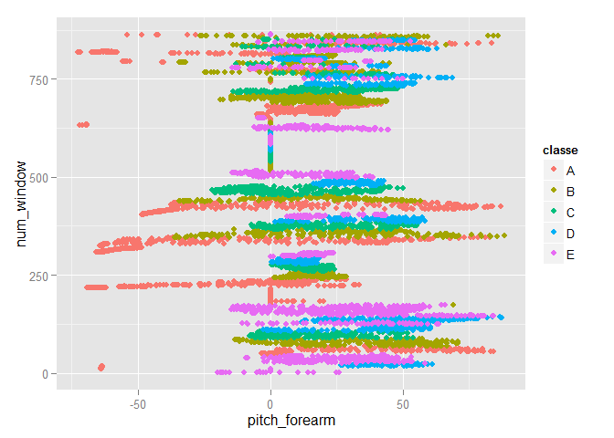

```r
qplot(x = pitch_forearm,y = num_window,data = training,colour = classe)
```

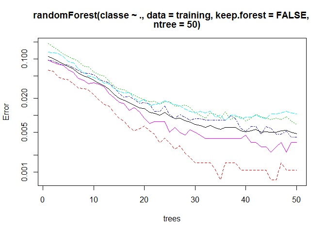

```r
plot(randomForest(classe ~ ., data=training, keep.forest=FALSE, ntree=50), log="y")
```

## 3.3 Model Testing for Out-of-Sample Error

```r
conf <- confusionMatrix(testing$classe, predict(rfTune, testing))
conf$table
```

```
##           Reference
## Prediction    A    B    C    D    E
##          A 2790    0    0    0    0
##          B    0 1897    1    0    0
##          C    0    2 1708    1    0
##          D    0    0    0 1608    0
##          E    0    0    0    1 1802
```

```r
etable <- data.frame(actual=testing$classe,
                     predicted=predict(rfTune, testing))
eRate <- nrow(etable[!etable$actual==etable$predicted,]) / nrow(etable)
```

# 4 Model Scoring New Data

## 4.1 Pre-Processing New Data

- Format all number based variables as numeric
- Remove variables `X`,`user_name`, and `new_window` from new testing data as they were not used to build the model

```r
for (i in 1:length(names(testingData))) {
        if (grepl("dumbbell|forearm|arm|belt",names(testingData)[i])){
                testingData[,i] <- as.numeric(testingData[,i])
        }
}

testingData <- testingData[,c(-1,-2,-6)]
```

## 4.2 Data Cleansing

- Replaces all missing values (NA) with 0

```r
for (j in 1:length(names(testingData))) {
        for (i in 1:nrow(testingData)) {
              if (is.na(testingData[i,j])) {testingData[i,j] <- 0}
        }
}
```

## 4.3 Creating Dummy Variables

- Convert all factor variables to dummy variables

```r
dummies <- dummyVars( ~ ., testingData, levelsOnly = TRUE)
numData <- as.data.frame(predict(dummies, testingData))
```

## 4.4 Predicting with Random Forest Model

- Predicts the `classe` for each of the 20 testing cases

```r
answers = as.character(predict(rfTune, numData))

pml_write_files = function(x){
  n = length(x)
  for(i in 1:n){
    filename = paste0("problem_id_",i,".txt")
    write.table(x[i],file=filename,quote=FALSE,row.names=FALSE,col.names=FALSE)
  }
}

pml_write_files(answers)
```